# TP 6 : Apprentissage supervisé et classification naïve bayésienne

- Montrer tout le code
- Cacher tout le code
- Voir les sources

Compléments de Mathématiques 2 - L3 MIASHS

Auteur·rice

Lola Etiévant

Date de publication

2026

# 1 Préparation des données

## 1.1 Chargement du jeu de données

```r
qualitative_vars  <- read.csv("../TP2/titanic_pre_processed_qualitative_vars.csv", stringsAsFactors = TRUE)
quantitative_vars <- read.csv("../TP2/titanic_pre_processed_quantitative_vars.csv")
target            <- read.csv("../TP2/titanic_pre_processed_target.csv")
target            <- as.factor(target$x)
```

Suppression des observations avec valeurs manquantes pour `Sex` (seulement 2 sur 876, soit < 0.2%) :

```r
isMissingSex <- which(is.na(qualitative_vars$Sex) | qualitative_vars$Sex == "")
if (length(isMissingSex) > 0) {
  qualitative_vars  <- qualitative_vars[-isMissingSex, ]
  quantitative_vars <- quantitative_vars[-isMissingSex, ]
  target            <- target[-isMissingSex]
}
```

## 1.2 Vérification des types

```r
qualitative_vars$Pclass  <- as.factor(qualitative_vars$Pclass)
qualitative_vars$Sex     <- as.factor(qualitative_vars$Sex)
qualitative_vars$withFam <- as.factor(qualitative_vars$withFam)

str(qualitative_vars)
```

```
'data.frame':   874 obs. of  4 variables:
 $ Age_cat: Factor w/ 4 levels "Adolescent","Adulte",..: 2 2 2 2 2 NA 2 3 2 1 ...
 $ Pclass : Factor w/ 3 levels "1","2","3": 3 1 3 1 3 3 1 3 3 2 ...
 $ Sex    : Factor w/ 3 levels "","female","male": 3 2 2 2 3 3 3 3 2 2 ...
 $ withFam: Factor w/ 2 levels "0","1": 2 2 1 2 1 1 1 2 2 2 ...
```

```r
str(quantitative_vars)
```

```
'data.frame':   874 obs. of  5 variables:
 $ Age  : num  22 38 26 35 35 NA 54 2 27 14 ...
 $ SibSp: int  1 1 0 1 0 0 0 3 0 1 ...
 $ Parch: int  0 0 0 0 0 0 0 1 2 0 ...
 $ Fam  : int  1 1 0 1 0 0 0 4 2 1 ...
 $ Fare : num  7.25 71.28 7.92 53.1 8.05 ...
```

```r
str(target)
```

```
 Factor w/ 2 levels "Décédé","Survivant": 1 2 2 2 1 1 1 1 2 2 ...
```

# 2 Classifieur bayésien naïf

## 2.1 Rappel

**NoteHyperparamètre**

Il n’y a **pas d’hyperparamètre** à choisir avec la méthode de classification naïve bayésienne. Il n’y a donc pas besoin de jeu de validation : on partage le jeu de données en **deux parties** seulement (Train / Test).

## 2.2 Variables explicatives quantitatives

**NoteEncoding et normalisation**

Avec le classifieur naïf bayésien, on n’a **pas besoin** de transformer les variables qualitatives (dummy coding ou label encoding) ni de normaliser/standardiser les variables quantitatives. Le classifieur travaille directement avec les distributions conditionnelles de chaque variable.

En revanche, on fait l’hypothèse que les variables explicatives sont **indépendantes conditionnellement à la target**, et pour les variables quantitatives on suppose qu’elles suivent une **loi normale** conditionnellement à la target.

On exclut `Fam`, `Parch` et `SibSp` puisqu’on utilisera `withFam`. Vérifions l’hypothèse de normalité pour `Age` et `Fare` :

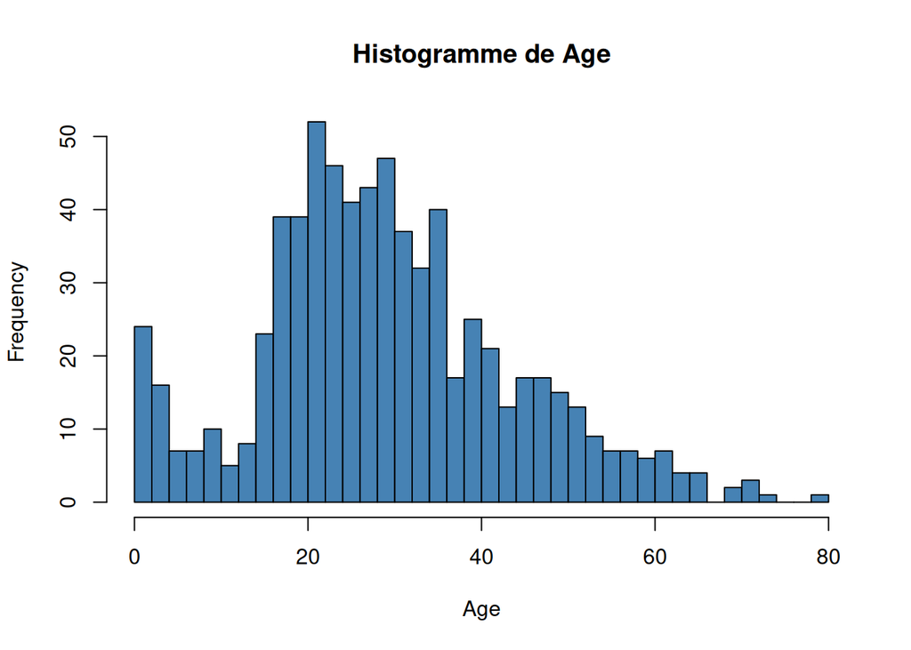

Figure 1: Distribution de Age

```r
hist(quantitative_vars$Age, breaks = 30, col = "steelblue",
     main = "Histogramme de Age", xlab = "Age")
```

`Age` semble à peu près suivre une distribution unimodale, compatible avec l’hypothèse gaussienne.

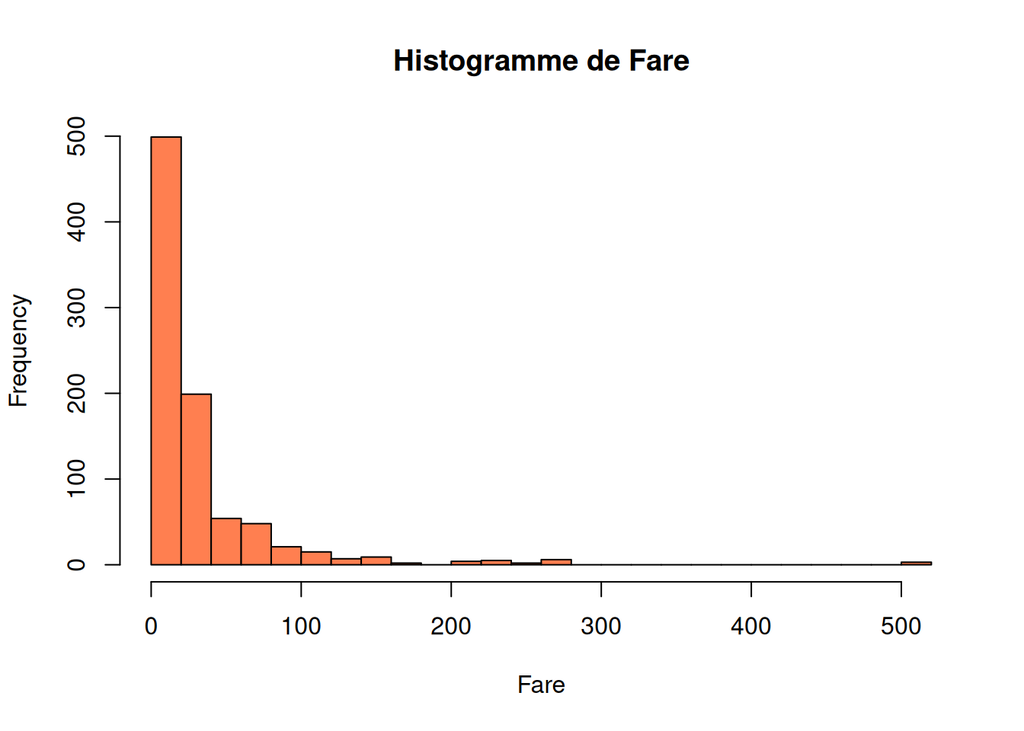

Figure 2: Distribution de Fare

```r
hist(quantitative_vars$Fare, breaks = 30, col = "coral",
     main = "Histogramme de Fare", xlab = "Fare")
```

`Fare` est très asymétrique à droite (skewed right), ce qui n’est **pas compatible** avec l’hypothèse gaussienne. On applique une transformation **logarithmique** pour se rapprocher d’une distribution normale :

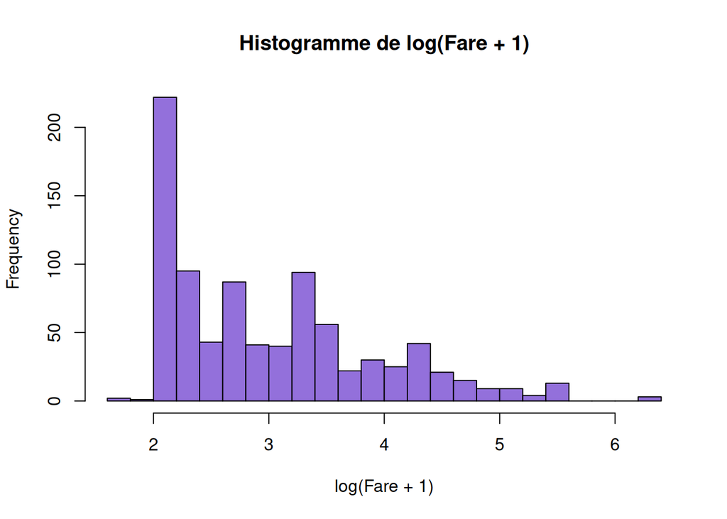

Figure 3: Distribution de log(Fare + 1)

```r
quantitative_vars$logFare <- log(quantitative_vars$Fare + 1)

hist(quantitative_vars$logFare, breaks = 30, col = "mediumpurple",
     main = "Histogramme de log(Fare + 1)", xlab = "log(Fare + 1)")
```

La distribution de `log(Fare + 1)` est bien plus proche d’une gaussienne.

## 2.3 Variables explicatives utilisées pour la prédiction

```r
predictive_vars <- data.frame(
  qualitative_vars[, c("Pclass", "Sex", "withFam")],
  Age     = quantitative_vars$Age,
  logFare = quantitative_vars$logFare
)
str(predictive_vars)
```

```
'data.frame':   874 obs. of  5 variables:
 $ Pclass : Factor w/ 3 levels "1","2","3": 3 1 3 1 3 3 1 3 3 2 ...
 $ Sex    : Factor w/ 3 levels "","female","male": 3 2 2 2 3 3 3 3 2 2 ...
 $ withFam: Factor w/ 2 levels "0","1": 2 2 1 2 1 1 1 2 2 2 ...
 $ Age    : num  22 38 26 35 35 NA 54 2 27 14 ...
 $ logFare: num  2.11 4.28 2.19 3.99 2.2 ...
```

# 3 Classifieur naïf bayésien avec Holdout

## 3.1 Partage du jeu de données

```r
set.seed(1234)
n <- nrow(predictive_vars)
inTrain <- sample(1:n, size = round(0.8 * n))

predictive_vars_train <- predictive_vars[inTrain, ]
predictive_vars_test  <- predictive_vars[-inTrain, ]
target_train          <- target[inTrain]
target_test           <- target[-inTrain]
```

## 3.2 Gestion des données manquantes

On utilise la médiane imputation pour `Age`, en calculant la médiane sur le Train uniquement pour éviter le data leakage :

```r
library(caret)

Proc <- preProcess(predictive_vars_train, method = "medianImpute")
predictive_vars_train <- predict(Proc, predictive_vars_train)
predictive_vars_test  <- predict(Proc, predictive_vars_test)
```

## 3.3 Phase d’apprentissage

```r
library(naivebayes)

classif <- naive_bayes(x = predictive_vars_train, y = target_train)
```

**AstuceQue retourne `classif` ?**

L’objet retourné contient les distributions conditionnelles estimées de chaque variable explicative sachant la target :

- Pour les variables **qualitatives** : les probabilités conditionnelles $\hat{P}(X^{(l)} = x | Y = y)$ (tables de probabilités).
- Pour les variables **quantitatives** : les paramètres $(\hat{\mu}, \hat{\sigma})$ de la loi normale conditionnelle estimée.
- Les **probabilités a priori** $\hat{P}(Y = y)$.

```r
classif
```

```
================================= Naive Bayes ==================================

Call:
naive_bayes.default(x = predictive_vars_train, y = target_train)

--------------------------------------------------------------------------------

Laplace smoothing: 0

--------------------------------------------------------------------------------

A priori probabilities:

   Décédé Survivant
0.6051502 0.3948498

--------------------------------------------------------------------------------

Tables:

--------------------------------------------------------------------------------
:: Pclass (Categorical)
--------------------------------------------------------------------------------

Pclass    Décédé Survivant
     1 0.1489362 0.3876812
     2 0.1607565 0.2536232
     3 0.6903073 0.3586957

--------------------------------------------------------------------------------
:: Sex (Categorical)
--------------------------------------------------------------------------------

Sex         Décédé Survivant
         0.0000000 0.0000000
  female 0.1442080 0.6811594
  male   0.8557920 0.3188406

--------------------------------------------------------------------------------
:: withFam (Bernoulli)
```

[output cut: 8 more lines]

```
--------------------------------------------------------------------------------

Age      Décédé Survivant
  mean 29.74113  27.99518
  sd   12.15621  13.73591

--------------------------------------------------------------------------------
:: logFare (Gaussian)
--------------------------------------------------------------------------------

logFare    Décédé Survivant
   mean 2.7888601 3.3620149
   sd   0.7740001 0.9716655

--------------------------------------------------------------------------------
```

Représentation graphique des distributions conditionnelles :

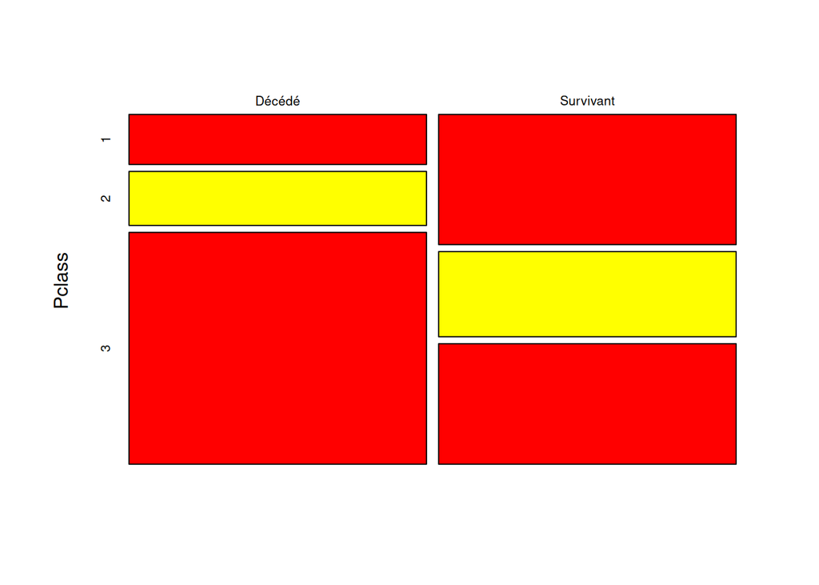

Figure 4: Distributions conditionnelles des variables explicatives

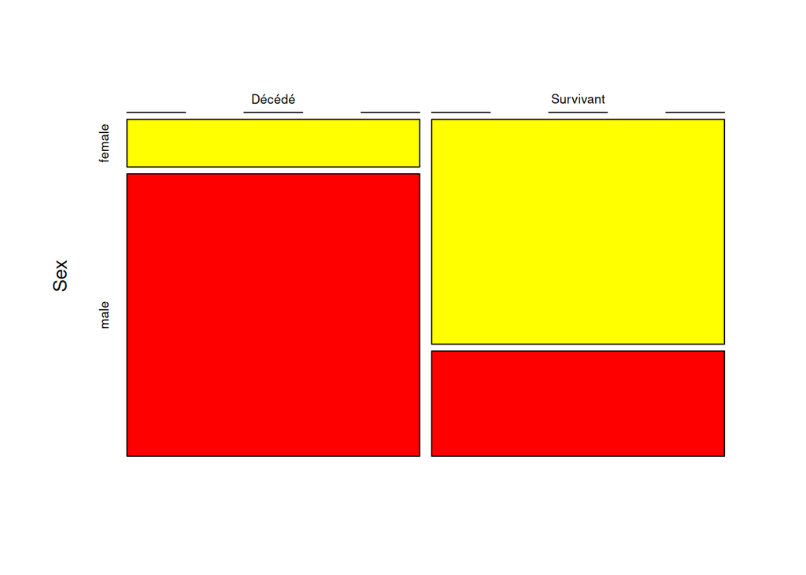

Figure 5: Distributions conditionnelles des variables explicatives

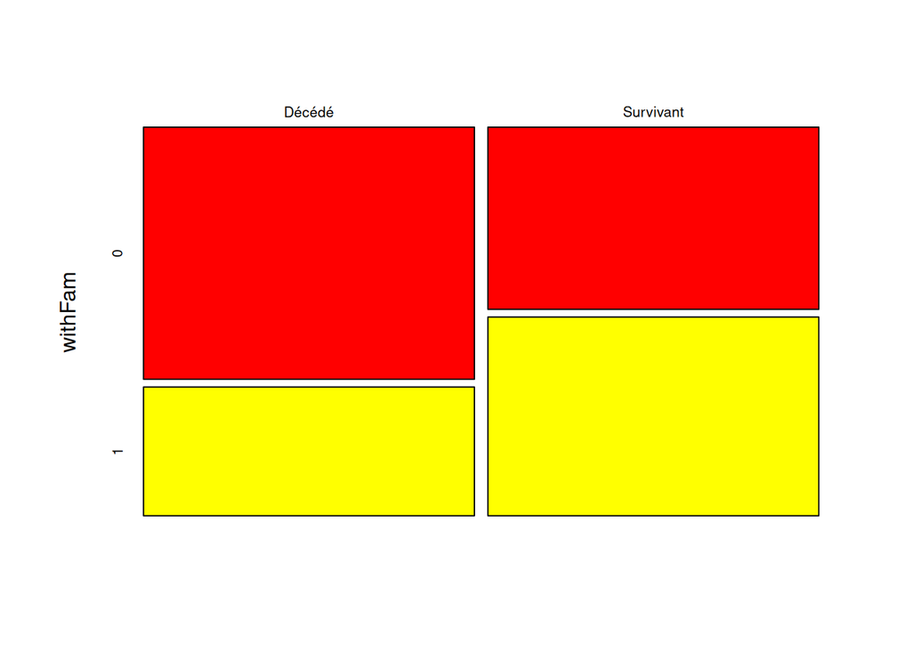

Figure 6: Distributions conditionnelles des variables explicatives

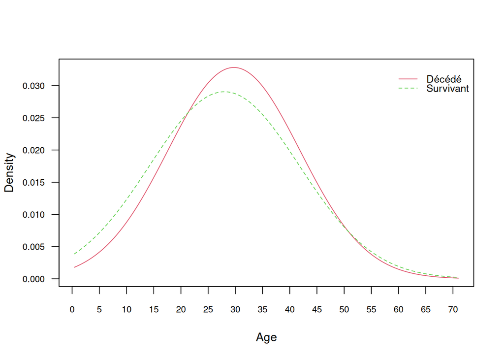

Figure 7: Distributions conditionnelles des variables explicatives

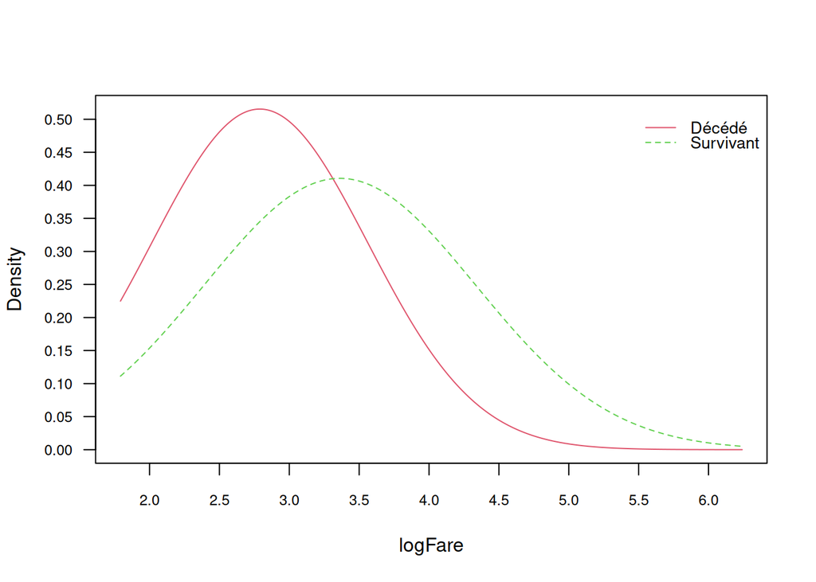

Figure 8: Distributions conditionnelles des variables explicatives

```r
plot(classif, prob = "conditional")
```

**NoteLaplace smoothing**

Si une combinaison catégorie-réponse n’apparaît pas dans les données d’entraînement, on obtient $\hat{P}(X^{(l)} = x^{(l)} | Y) = 0$. L’argument `laplace` de `naive_bayes` permet d’appliquer un lissage additif pour éviter ce problème.

## 3.4 Prédiction des probabilités

```r
pred <- predict(classif, predictive_vars_test, type = "prob")
head(pred)
```

```
        Décédé  Survivant
[1,] 0.9610238 0.03897618
[2,] 0.7561169 0.24388313
[3,] 0.4372293 0.56277066
[4,] 0.2715813 0.72841872
[5,] 0.8677017 0.13229833
[6,] 0.6546453 0.34535469
```

Cette ligne prédit pour chaque individu du jeu de test la **probabilité d’appartenir à chaque catégorie** de la target (Décédé / Survivant).

Pour obtenir directement la **catégorie prédite**, on utilise `type = "class"` au lieu de `type = "prob"`.

## 3.5 Prédiction et évaluation

```r
target_pred <- predict(classif, predictive_vars_test, type = "class")

cm <- confusionMatrix(target_pred, target_test, positive = "Survivant")
cm
```

```
Confusion Matrix and Statistics

           Reference
Prediction  Décédé Survivant
  Décédé        95        17
  Survivant     16        47

               Accuracy : 0.8114
                 95% CI : (0.7455, 0.8665)
    No Information Rate : 0.6343
    P-Value [Acc > NIR] : 2.542e-07

                  Kappa : 0.5922

 Mcnemar's Test P-Value : 1

            Sensitivity : 0.7344
            Specificity : 0.8559
         Pos Pred Value : 0.7460
         Neg Pred Value : 0.8482
             Prevalence : 0.3657
         Detection Rate : 0.2686
   Detection Prevalence : 0.3600
      Balanced Accuracy : 0.7951

       'Positive' Class : Survivant
```

```r
cat("Accuracy  :", round(cm$overall["Accuracy"], 4), "\n")
```

```
Accuracy  : 0.8114
```

```r
cat("Recall    :", round(cm$byClass["Sensitivity"], 4), "\n")
```

```
Recall    : 0.7344
```

```r
cat("Precision :", round(cm$byClass["Pos Pred Value"], 4), "\n")
```

```
Precision : 0.746
```

**AvertissementSensibilité au seed**

En recompilant avec d’autres seeds, les métriques varient car le partage Train/Test est aléatoire. On pourrait proposer d’utiliser la **validation croisée** pour obtenir des estimations plus stables des performances.

## 3.6 Pour aller plus loin : importance des variables

On peut visualiser l’influence de chaque variable explicative sur les probabilités prédites.

Pour une variable **qualitative** comme `Sex` :

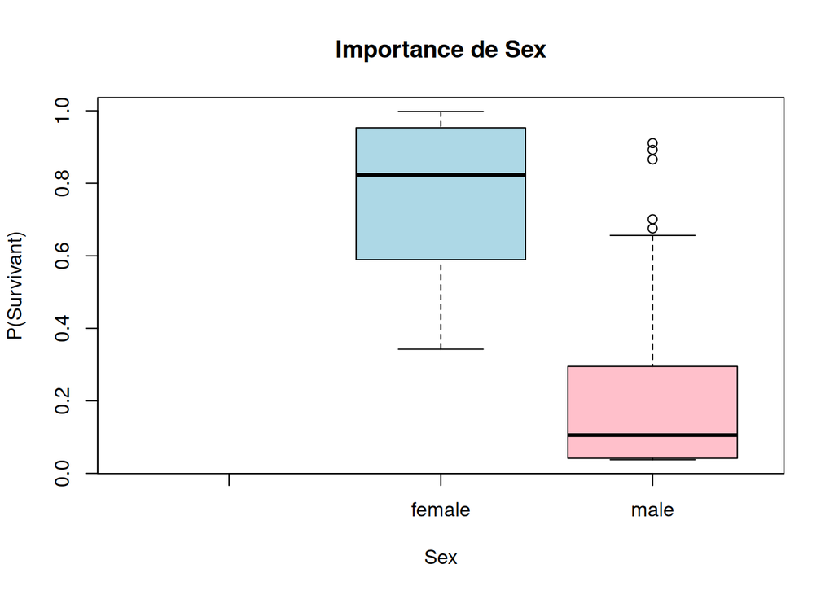

Figure 9: Probabilité prédite de survivre selon Sex

```r
boxplot(pred[, 2] ~ predictive_vars_test$Sex, col = c("pink", "lightblue"),
        main = "Importance de Sex", ylab = "P(Survivant)", xlab = "Sex")
```

Pour une variable **quantitative** comme `logFare`, on utiliserait un **nuage de points** (scatter plot) :

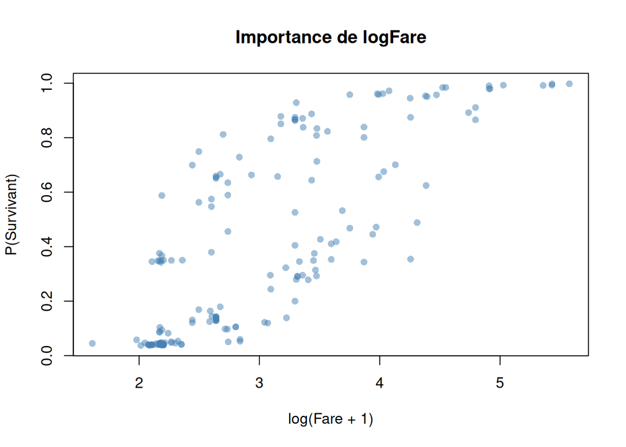

Figure 10: Probabilité prédite de survivre selon log(Fare)

```r
plot(predictive_vars_test$logFare, pred[, 2],
     pch = 16, col = adjustcolor("steelblue", 0.5),
     xlab = "log(Fare + 1)", ylab = "P(Survivant)",
     main = "Importance de logFare")
```

# 4 Classifieur naïf bayésien avec 10-fold cross-validation

## 4.1 Assignation des folds

```r
set.seed(1234)
nfolds <- 10
folds  <- sample(1:nfolds, n, replace = TRUE)
```

## 4.2 Boucle de validation croisée

```r
accuracy_fold  <- numeric(nfolds)
recall_fold    <- numeric(nfolds)
precision_fold <- numeric(nfolds)

for (k in 1:nfolds) {
  inFold <- which(folds == k)

  predictive_vars_test  <- predictive_vars[inFold, ]
  target_test           <- target[inFold]
  predictive_vars_train <- predictive_vars[-inFold, ]
  target_train          <- target[-inFold]

  # Median imputation (sans data leakage)
  Proc <- preProcess(predictive_vars_train, method = "medianImpute")
  predictive_vars_train <- predict(Proc, predictive_vars_train)
  predictive_vars_test  <- predict(Proc, predictive_vars_test)

  # Apprentissage et prédiction
  classif     <- naive_bayes(x = predictive_vars_train, y = target_train)
  target_pred <- predict(classif, predictive_vars_test, type = "class")

  # Calcul des métriques
  cm <- confusionMatrix(target_pred, target_test, positive = "Survivant")

  accuracy_fold[k]  <- cm$overall["Accuracy"]
  recall_fold[k]    <- cm$byClass["Sensitivity"]
  precision_fold[k] <- cm$byClass["Pos Pred Value"]
}

names(accuracy_fold)  <- paste0("fold_", 1:nfolds)
names(recall_fold)    <- paste0("fold_", 1:nfolds)
names(precision_fold) <- paste0("fold_", 1:nfolds)
```

## 4.3 Résultats par fold

```r
accuracy_fold
```

```
   fold_1    fold_2    fold_3    fold_4    fold_5    fold_6    fold_7    fold_8
0.7555556 0.7125000 0.7500000 0.7272727 0.7674419 0.7345133 0.7241379 0.8089888
   fold_9   fold_10
0.7236842 0.8000000
```

```r
recall_fold
```

```
   fold_1    fold_2    fold_3    fold_4    fold_5    fold_6    fold_7    fold_8
0.7187500 0.5416667 0.5937500 0.6571429 0.5789474 0.6296296 0.6363636 0.8437500
   fold_9   fold_10
0.5862069 0.7741935
```

```r
precision_fold
```

```
   fold_1    fold_2    fold_3    fold_4    fold_5    fold_6    fold_7    fold_8
0.6388889 0.5200000 0.6333333 0.7187500 0.8461538 0.7727273 0.6363636 0.6923077
   fold_9   fold_10
0.6538462 0.7272727
```

**AstuceCommentaire**

Les valeurs varient d’un fold à l’autre car chaque fold utilise un sous-ensemble différent pour le test. C’est normal et c’est précisément ce que la CV cherche à capturer : la variabilité des performances selon le découpage.

## 4.4 Moyennes cross-validées

```r
cat("10-fold CV Mean Accuracy  :", round(mean(accuracy_fold), 4), "\n")
```

```
10-fold CV Mean Accuracy  : 0.7504
```

```r
cat("10-fold CV Mean Recall    :", round(mean(recall_fold), 4), "\n")
```

```
10-fold CV Mean Recall    : 0.656
```

```r
cat("10-fold CV Mean Precision :", round(mean(precision_fold, na.rm = TRUE), 4), "\n")
```

```
10-fold CV Mean Precision : 0.684
```

**NoteStabilité**

En recompilant avec une autre seed, les résultats moyens sont **beaucoup plus stables** qu’avec le Holdout simple. C’est l’avantage principal de la validation croisée : elle réduit la dépendance au découpage aléatoire.

# 5 Pour aller plus loin

## 5.1 Bonus : version catégorielle de Age

On crée 4 catégories : enfants (< 13), adolescents (13-18), adultes (18-60), seniors (> 60).

### 5.1.1 Avec Holdout

```r
Age_cat <- cut(quantitative_vars$Age,
               breaks = c(-Inf, 13, 18, 60, Inf),
               labels = c("Enfant", "Adolescent", "Adulte", "Senior"))

predictive_vars_cat <- data.frame(
  qualitative_vars[, c("Pclass", "Sex", "withFam")],
  Age_cat = Age_cat,
  logFare = quantitative_vars$logFare
)

set.seed(1234)
inTrain <- sample(1:n, size = round(0.8 * n))

train_cat <- predictive_vars_cat[inTrain, ]
test_cat  <- predictive_vars_cat[-inTrain, ]
y_train   <- target[inTrain]
y_test    <- target[-inTrain]

# Imputation mode pour Age_cat, médiane pour logFare
# (pas de NA dans logFare, donc on gère juste Age_cat)
# Si Age est NA, Age_cat sera NA => on impute par le mode
mode_age_cat <- names(which.max(table(train_cat$Age_cat)))
train_cat$Age_cat[is.na(train_cat$Age_cat)] <- mode_age_cat
test_cat$Age_cat[is.na(test_cat$Age_cat)]   <- mode_age_cat

classif_cat  <- naive_bayes(x = train_cat, y = y_train)
pred_cat     <- predict(classif_cat, test_cat, type = "class")
cm_cat       <- confusionMatrix(pred_cat, y_test, positive = "Survivant")

cat("Accuracy  :", round(cm_cat$overall["Accuracy"], 4), "\n")
```

```
Accuracy  : 0.8114
```

```r
cat("Recall    :", round(cm_cat$byClass["Sensitivity"], 4), "\n")
```

```
Recall    : 0.7188
```

```r
cat("Precision :", round(cm_cat$byClass["Pos Pred Value"], 4), "\n")
```

```
Precision : 0.7541
```

### 5.1.2 Avec 10-fold CV

```r
set.seed(1234)
folds_cat <- sample(1:nfolds, n, replace = TRUE)

acc_cat  <- numeric(nfolds)
rec_cat  <- numeric(nfolds)
prec_cat <- numeric(nfolds)

for (k in 1:nfolds) {
  inFold <- which(folds_cat == k)

  train_k <- predictive_vars_cat[-inFold, ]
  test_k  <- predictive_vars_cat[inFold, ]
  y_tr    <- target[-inFold]
  y_te    <- target[inFold]

  # Imputation mode pour Age_cat
  mode_val <- names(which.max(table(train_k$Age_cat)))
  train_k$Age_cat[is.na(train_k$Age_cat)] <- mode_val
  test_k$Age_cat[is.na(test_k$Age_cat)]   <- mode_val

  classif_k  <- naive_bayes(x = train_k, y = y_tr)
  pred_k     <- predict(classif_k, test_k, type = "class")
  cm_k       <- confusionMatrix(pred_k, y_te, positive = "Survivant")

  acc_cat[k]  <- cm_k$overall["Accuracy"]
  rec_cat[k]  <- cm_k$byClass["Sensitivity"]
  prec_cat[k] <- cm_k$byClass["Pos Pred Value"]
}

cat("10-fold CV Mean Accuracy  :", round(mean(acc_cat), 4), "\n")
```

```
10-fold CV Mean Accuracy  : 0.7574
```

```r
cat("10-fold CV Mean Recall    :", round(mean(rec_cat), 4), "\n")
```

```
10-fold CV Mean Recall    : 0.6639
```

```r
cat("10-fold CV Mean Precision :", round(mean(prec_cat, na.rm = TRUE), 4), "\n")
```

```
10-fold CV Mean Precision : 0.6921
```

## 5.2 Bonus : version catégorielle de Fare

```r
Fare_cat <- cut(quantitative_vars$Fare,
                breaks = quantile(quantitative_vars$Fare, probs = c(0, 0.25, 0.5, 0.75, 1), na.rm = TRUE),
                labels = c("Bas", "Moyen-Bas", "Moyen-Haut", "Haut"),
                include.lowest = TRUE)

predictive_vars_allcat <- data.frame(
  qualitative_vars[, c("Pclass", "Sex", "withFam")],
  Age_cat  = Age_cat,
  Fare_cat = Fare_cat
)

set.seed(1234)
folds_allcat <- sample(1:nfolds, n, replace = TRUE)

acc_allcat  <- numeric(nfolds)
rec_allcat  <- numeric(nfolds)
prec_allcat <- numeric(nfolds)

for (k in 1:nfolds) {
  inFold <- which(folds_allcat == k)

  train_k <- predictive_vars_allcat[-inFold, ]
  test_k  <- predictive_vars_allcat[inFold, ]
  y_tr    <- target[-inFold]
  y_te    <- target[inFold]

  # Imputation mode
  mode_age  <- names(which.max(table(train_k$Age_cat)))
  mode_fare <- names(which.max(table(train_k$Fare_cat)))
  train_k$Age_cat[is.na(train_k$Age_cat)]   <- mode_age
  test_k$Age_cat[is.na(test_k$Age_cat)]     <- mode_age
  train_k$Fare_cat[is.na(train_k$Fare_cat)] <- mode_fare
  test_k$Fare_cat[is.na(test_k$Fare_cat)]   <- mode_fare

  classif_k  <- naive_bayes(x = train_k, y = y_tr)
  pred_k     <- predict(classif_k, test_k, type = "class")
  cm_k       <- confusionMatrix(pred_k, y_te, positive = "Survivant")

  acc_allcat[k]  <- cm_k$overall["Accuracy"]
  rec_allcat[k]  <- cm_k$byClass["Sensitivity"]
  prec_allcat[k] <- cm_k$byClass["Pos Pred Value"]
}

cat("10-fold CV Mean Accuracy  :", round(mean(acc_allcat), 4), "\n")
```

```
10-fold CV Mean Accuracy  : 0.7464
```

```r
cat("10-fold CV Mean Recall    :", round(mean(rec_allcat), 4), "\n")
```

```
10-fold CV Mean Recall    : 0.6669
```

```r
cat("10-fold CV Mean Precision :", round(mean(prec_allcat, na.rm = TRUE), 4), "\n")
```

```
10-fold CV Mean Precision : 0.6706
```